# (Analyzing Ford GoBike)

## by (Adel Almutairi)

## Investigation Overview

> The golas that I am going to present are the results between users type

## Dataset Overview

> 1- Explore monthly usage of the bike share system per user type

> 2- Weekly usage of the bike share system per user type

> 3- Hourly usage of the bike share system per user type

## Start time month

Monthly usage of the bike share system per user type

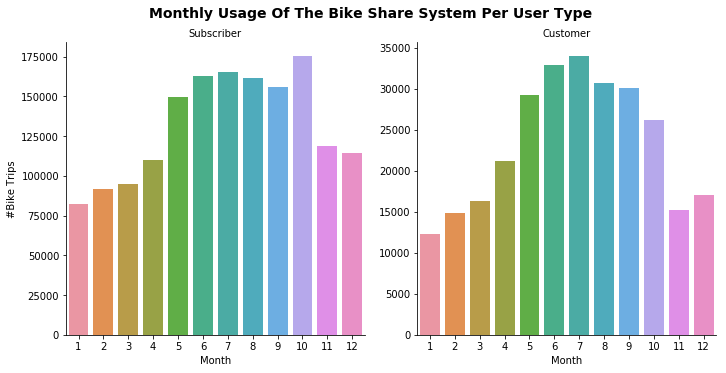

```python
# monthly usege of the bike sharing system per user type
plt.figure(figsize=[ 11.69, 8.27]);
g = sns.catplot(data=df_clean, x='start_time_month', col="user_type", kind='count', sharey = False)
g.set_axis_labels("Month", "#Bike Trips")
g.set_titles("{col_name}")
g.fig.suptitle('Monthly usage of the bike share system per user type'.title(), y=1.03, fontsize=14, fontweight='semibold');
```

**Customers: demand is high around summertime, reaching its peak in July. Customers are most probably tourists, or the occasional riders who visit the Bay Area. Subscribers: the highest demand is from May till October, reaching it's peak in October. Subscribers are most likely riders using the bikes for their daily commute**

## Start time weekday

Weekly usage of the bike share system per user type

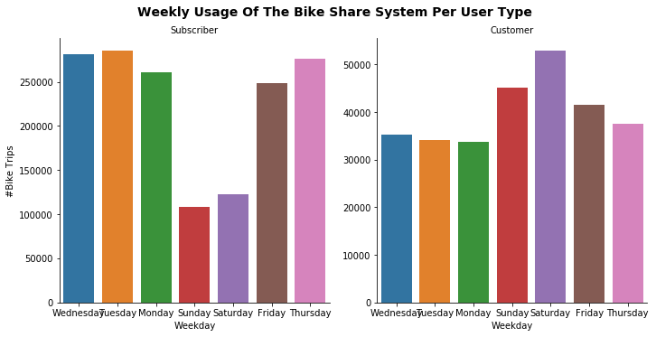

```python
# weekday usege of the bike sharing system per user type
plt.figure(figsize=[ 11.69, 8.27]);
weekday = ['Mon', 'Tue', 'Wed', 'Thu', 'Fri', 'Sat', 'Sun']
g = sns.catplot(data=df_clean, x='start_time_weekday', col="user_type", kind='count' , sharey = False)
g.set_axis_labels("Weekday", "#Bike Trips")
g.set_titles("{col_name}")
g.fig.suptitle('Weekly usage of the bike share system per user type'.title(), y=1.03, fontsize=14, fontweight='semibold');
```

**There is a different trend on which days customers and subscribers rent bikes. As mentioned above customers are most probably occasional riders and tourist who use the bike sharing system on holiday or weekend trips. On the other hand, subscribers are most probably daily work/school commuters who use the system within a week**

## Start time hour

Hourly usage of the bike share system per user type

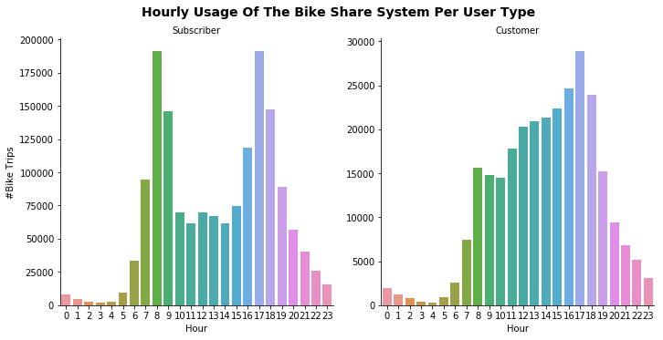

```python
# hourly usege of the bike sharing system per user type
plt.figure(figsize=[ 11.69, 8.27]);
g = sns.catplot(data=df_clean, x='start_time_hour', col="user_type", kind='count', sharey = False)
g.set_axis_labels("Hour", "#Bike Trips")
g.set_titles("{col_name}")
g.fig.suptitle('Hourly usage of the bike share system per user type'.title(), y=1.03, fontsize=14, fontweight='semibold');
```

**There is also a different trend of when during the day bikes are rented most often. Customers use bikes mainly between 8 am - 7 pm, reaching the renting peak around 5pm. Subscribers on the other side use the system at around 8-9am and 5-6pm when they go and come back from work**